# Perwalian S2 Statistika Terapan FMIPA Unpad | Semester Ganjil 2026/2027

Pasca Sarjana Statistika FMIPA UNPAD

Magister Statistika Terapan · Universitas Padjadjaran

IDEN

Menu Program Informasi S2 Statistika Terapan

[Kembali ke Tampilan Awal](https://statistika-unpad.github.io/pasca-statistika-web/)

Program Pendidikan

Dokumentasi

Perwalian Hybrid · Angkatan 2026

Berita Akademik · 13 Agustus 2026

# Perwalian Mahasiswa Baru S2 Statistika Terapan

Menata kurikulum, sistem perkuliahan, PJJ, publikasi, project, dan strategi penyelesaian studi sejak semester pertama.

📅 Kamis, 13 Agustus 2026 🕑 14.00 WIB – selesai 📍 Lantai 3 Gedung Statistika 💻 Hybrid

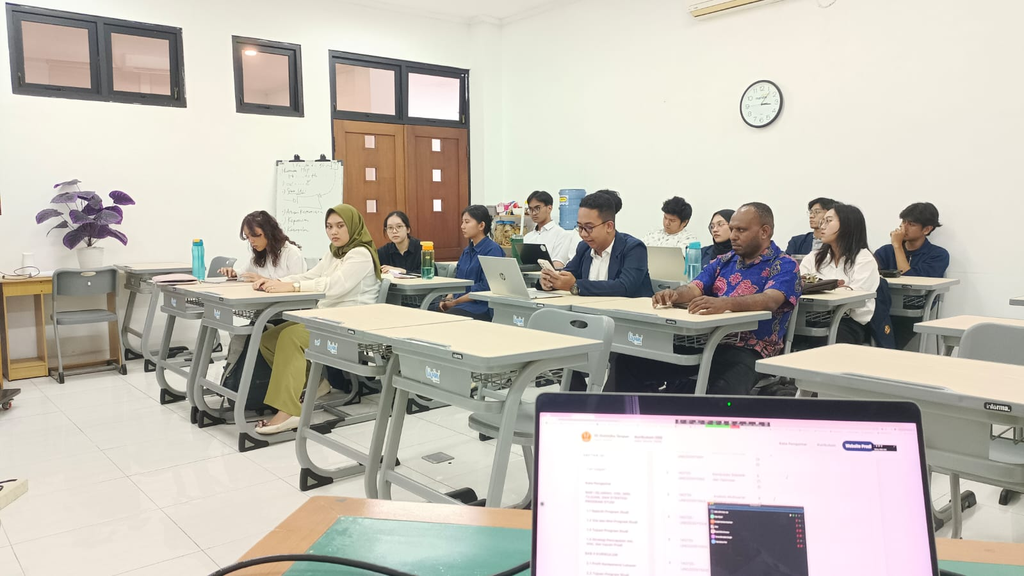

Mahasiswa baru Angkatan 2026 mengikuti sesi perwalian di ruang kuliah S2 Statistika Terapan FMIPA Unpad. Sebagian peserta mengikuti secara daring.

**25**Mahasiswa baru Angkatan 2026

**Hybrid**Luring dan daring

**3 Semester**Target perjalanan studi

**1,5 Tahun**Strategi penyelesaian

## Perwalian sebagai Awal Perjalanan Akademik

**Jatinangor, 13 Agustus 2026** — Program Studi S2 Statistika Terapan FMIPA Universitas Padjadjaran menyelenggarakan Perwalian Mahasiswa Semester Ganjil Tahun Akademik 2026/2027 pada Kamis, 13 Agustus 2026 mulai pukul **14.00 WIB hingga selesai**. Kegiatan berlangsung secara **hybrid** di ruang kuliah S2 Statistika Terapan, Lantai 3 Gedung Statistika FMIPA Unpad, dan diikuti oleh seluruh **25 mahasiswa baru Angkatan 2026**.

Sesi perwalian dirancang lebih luas daripada sekadar pengisian KRS. Mahasiswa memperoleh gambaran mengenai kurikulum, mata kuliah PJJ, regulasi pembelajaran jarak jauh, sistem perkuliahan, project, publikasi ilmiah, serta strategi menyelesaikan studi dalam tiga semester atau 1,5 tahun.

Format hybrid memungkinkan mahasiswa yang belum dapat hadir secara fisik tetap mengikuti seluruh penjelasan akademik.

## Memahami Kurikulum Sejak Semester Pertama

Mahasiswa memperoleh penjelasan mengenai struktur Kurikulum S2 Statistika Terapan FMIPA Unpad, termasuk mata kuliah wajib, mata kuliah pilihan, tahapan penelitian, dan penyelesaian tesis. Fondasi metodologis dibangun melalui mata kuliah seperti Statistika Inferensial, Komputasi Statistik dan Optimasi, Analisis Multivariat Tingkat Lanjut, Analisis Regresi Tingkat Lanjut, Proses Stokastik Tingkat Lanjut, dan Analisis Deret Waktu Tingkat Lanjut.

Mahasiswa juga dikenalkan dengan berbagai bidang penguatan keilmuan, antara lain Analisis Spasial, Analisis Multilevel dan Longitudinal, Model Linear Generalisasi, Penambangan Data dan Kecerdasan Buatan, Pembelajaran Mesin, Epidemiologi, Analisis Survival, Sampling Survey, Analisis Teks, Analisis Citra, serta bidang aktuaria dan risiko.

“3 Semester, Kenapa Harus Lebih?”

Perencanaan studi dimulai sejak hari pertama—bukan ketika tesis sudah di depan mata.

## Perkuliahan Tatap Muka sebagai Prinsip Utama

Salah satu materi penting dalam perwalian adalah penjelasan regulasi perkuliahan online/PJJ. Jadwal perkuliahan yang telah ditetapkan wajib diikuti oleh seluruh mahasiswa dan pada prinsipnya dilaksanakan secara **tatap muka (offline)**.

Perkuliahan online hanya diperkenankan apabila mahasiswa memiliki alasan yang dapat dipertanggungjawabkan dan telah menyampaikannya kepada dosen pengampu. Mahasiswa yang mengikuti perkuliahan online tetap wajib mengikuti proses pembelajaran secara penuh dan aktif.

**Regulasi utama:** jumlah kehadiran perkuliahan online dibatasi maksimal **7 kali dari total 16 pertemuan**. Evaluasi pembelajaran seperti ujian dan/atau tugas utama pada prinsipnya dilaksanakan secara tatap muka, kecuali terdapat kebijakan khusus dari dosen pengampu.

## Perwalian Bukan Sekadar Mengisi KRS

Mahasiswa diarahkan untuk mendiskusikan sejak awal arah akademik, bidang minat, beban studi, rencana penelitian, dan target penyelesaian studi. Dengan ritme program magister yang cepat, mahasiswa perlu memahami hubungan antara perkuliahan, project, penelitian, publikasi, dan tesis sebagai satu perjalanan akademik yang terintegrasi.

## Project dan Publikasi Dipersiapkan Sejak Awal

Project mata kuliah diharapkan tidak berhenti sebagai tugas kelas, tetapi sebisa mungkin dikembangkan menjadi portofolio akademik, eksplorasi topik penelitian, bahan seminar, bahkan cikal bakal publikasi ilmiah. Mahasiswa juga didorong untuk membaca literatur mutakhir, membangun workflow komputasi yang reproducible, dan membahas peluang publikasi sejak semester pertama.

## Strategi Lulus dalam 1,5 Tahun

Target studi 1,5 tahun membutuhkan perencanaan yang disiplin. Mahasiswa diarahkan untuk mengikuti perkuliahan secara konsisten, mengeksplorasi topik penelitian sedini mungkin, berkomunikasi aktif dengan dosen dan calon pembimbing, mengintegrasikan project mata kuliah dengan rencana penelitian, serta menyiapkan milestone SUR, SKR, publikasi, dan tesis secara bertahap.

Percepatan masa studi tidak dimaknai sebagai mengurangi mutu akademik, tetapi sebagai upaya mengelola seluruh tahapan secara lebih terencana, terintegrasi, dan efisien.

## Menyiapkan Perjalanan Akademik Sejak Hari Pertama

Melalui kegiatan ini, mahasiswa baru diharapkan tidak hanya mengetahui mata kuliah yang akan diambil, tetapi memahami peta perjalanan akademik secara keseluruhan—mulai dari pembelajaran, project, pengembangan kompetensi, penelitian, seminar, publikasi, hingga penyelesaian tesis.

**Tiga semester. Terencana sejak awal. Berkualitas sampai akhir.**

### Agenda Utama

- Kurikulum dan mata kuliah
- Perwalian dan KRS
- Regulasi PJJ
- Sistem perkuliahan
- Strategi studi 1,5 tahun
- Project mata kuliah
- Publikasi ilmiah
- SUR – SKR – Tesis

### Informasi Kegiatan

**Hari**Kamis

**Tanggal**13 Agustus 2026

**Waktu**14.00 WIB – selesai

**Format**Hybrid

**Peserta**25 mahasiswa

**Lokasi**Lantai 3 Gedung Statistika

Visual Story

## Dokumentasi Perwalian

Suasana kelas, pelaksanaan hybrid, regulasi perkuliahan, dan akses informasi kurikulum dalam satu rangkaian dokumentasi.

Perwalian dilaksanakan secara hybrid.

Mahasiswa Angkatan 2026 mengikuti sesi akademik.

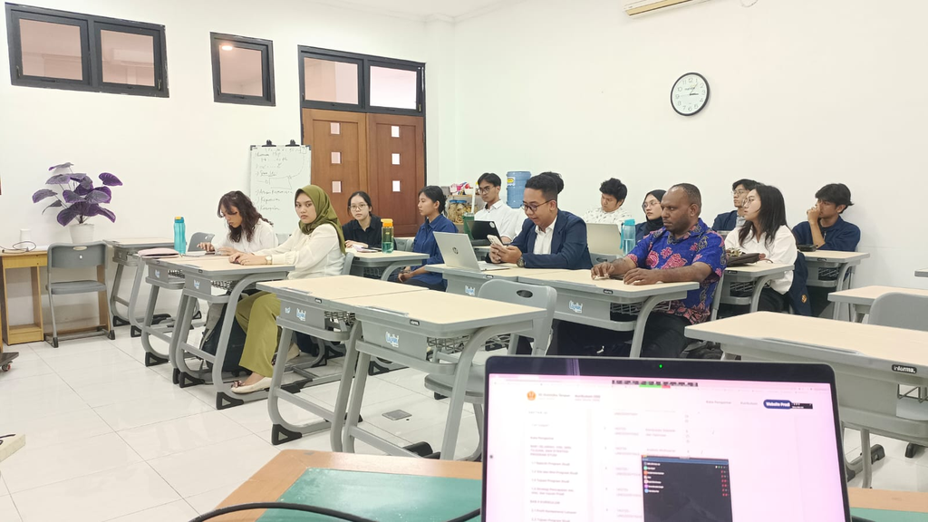

Suasana ruang kuliah S2 Statistika Terapan.

[figure not shown]

Mahasiswa dikenalkan dengan arsip dokumen kurikulum.

[figure not shown]

Surat Edaran Ketentuan Pelaksanaan Perkuliahan.

Dokumen Akademik

## Ketentuan Pelaksanaan Perkuliahan

Regulasi PJJ dibahas secara eksplisit agar fleksibilitas pembelajaran tidak mengurangi keterlibatan dan kualitas akademik.

[figure not shown]

### Tatap muka tetap menjadi prinsip utama.

Perkuliahan online merupakan fleksibilitas yang diberikan dengan ketentuan tertentu, bukan pengganti kehadiran akademik secara reguler.

1

Jadwal perkuliahan yang ditetapkan Program Studi wajib diikuti seluruh mahasiswa.

2

Perkuliahan pada prinsipnya dilaksanakan secara tatap muka dan kehadiran langsung bersifat wajib.

3

Perkuliahan online hanya diperkenankan dengan alasan yang dapat dipertanggungjawabkan.

4

Mahasiswa yang mengikuti kelas online wajib mengikuti proses pembelajaran secara penuh dan aktif.

5

Kehadiran online dibatasi maksimal 7 dari total 16 pertemuan.

6

Evaluasi pembelajaran pada prinsipnya dilaksanakan secara tatap muka.

Sumber Informasi

## Arsip Kurikulum Program Studi

Website pascasarjana menjadi salah satu pusat informasi akademik yang diperkenalkan kepada mahasiswa baru.

[figure not shown]

Tampilan arsip dokumen kurikulum pada website S2 Statistika Terapan FMIPA Unpad.

Tabel Akademik

## Daftar Mata Kuliah

Daftar mata kuliah yang menjadi bagian dari penjelasan kurikulum dan perencanaan perjalanan studi mahasiswa.

**32** mata kuliah

| No. | Kode MK | Mata Kuliah / Course | SKS |
| --- | --- | --- | --- |
| 1 | `140720-UND202511001` | **Statistika Inferensial** Inferential Statistics | 3 (3-0) |
| 2 | `140720-UND202511002` | **Komputasi Statistik dan Optimasi** Statistical Computing and Optimization | 3 (1-2) |
| 3 | `140720-UND202511003` | **Analisis Multivariat Tingkat Lanjut** Advanced Multivariate Analysis | 3 (2-1) |
| 4 | `140720-UND202511004` | **Analisis Regresi Tingkat Lanjut** Advanced Regression Analysis | 3 (2-1) |
| 5 | `140720-UND202511005` | **Proses Stokastik Tingkat Lanjut** Advanced Stochastic Processes | 3 (3-0) |
| 6 | `140720-UND202511006` | **Analisis Deret Waktu Tingkat Lanjut** Advanced Time Series Analysis | 3 (2-1) |
| 7 | `140720-UND202511007` | **Tinjauan Literatur Sistematis** Systematic Literature Review | 6 (3-3) |
| 8 | `140720-UND202511008` | **Asistensi Perkuliahan** Teaching Assistance | 3 (1-2) |
| 9 | `140720-UND202522001` | **Statistika Nonparametrik dan Pemodelan Fleksibel** Nonparametric Statistics and Flexible Modeling | 3 (2-1) |
| 10 | `140720-UND202522002` | **Penambangan Data dan Kecerdasan Buatan** Data Mining and Artificial Intelligence | 3 (2-1) |
| 11 | `140720-UND202522003` | **Pemodelan Persamaan Struktural** Structural Equation Modeling | 3 (2-1) |
| 12 | `140720-UND202522004` | **Analisis Spasial** Spatial Analysis | 3 (2-1) |
| 13 | `140720-UND202522005` | **Analisis Multilevel dan Longitudinal** Multilevel and Longitudinal Analysis | 3 (2-1) |
| 14 | `140720-UND202522006` | **Model Linear Generalisasi** Generalized Linear Models | 3 (2-1) |
| 15 | `140720-UND202522007` | **Matematika Keuangan** Financial Mathematics | 3 (2-1) |
| 16 | `140720-UND202522008` | **Desain Eksperimen** Experimental Design | 3 (2-1) |
| 17 | `140720-UND202522009` | **Teori Antrian** Queueing Theory | 3 (2-1) |
| 18 | `140720-UND202522010` | **Matematika Aktuaria 1** Actuarial Mathematics I | 3 (2-1) |
| 19 | `140720-UND202522011` | **Matematika Aktuaria 2** Actuarial Mathematics II | 3 (2-1) |
| 20 | `140720-UND202522012` | **Analisis Survival** Survival Analysis | 3 (2-1) |
| 21 | `140720-UND202522013` | **Teori Risiko** Risk Theory | 3 (2-1) |
| 22 | `140720-UND202522014` | **Epidemiologi** Epidemiology | 3 (2-1) |
| 23 | `140720-UND202522015` | **Pembelajaran Mesin** Machine Learning | 3 (2-1) |
| 24 | `140720-UND202522016` | **Analisis Citra** Image Analysis | 3 (2-1) |
| 25 | `140720-UND202522017` | **Analisis Teks** Text Analytics | 3 (2-1) |
| 26 | `140720-UND202522018` | **Basis Data** Basis Data | 3 (2-1) |
| 27 | `140720-UND202522019` | **Sampling Survey** Sampling Survey | 3 (2-1) |
| 28 | `140720-UND202503001` | **Pembicara Seminar Nasional/Internasional** National/International Seminar Speaker | 3 (2-1) |
| 29 | `140720-UND202503002` | **Seminar Usulan Riset (SUR)** Research Proposal Seminar (SUR) | 2 (1-1) |
| 30 | `140720-UND202503003` | **Seminar Kemajuan Riset (SKR)** Research Progress Seminar (SKR) | 4 (2-2) |
| 31 | `140720-UND202503004` | **Publikasi** Publication | 6 (3-3) |
| 32 | `140720-UND202503005` | **Sidang Akhir Magister (Tesis)** Master’s Thesis Defense | 6 (3-3) |

### Kenali lebih dekat S2 Statistika Terapan FMIPA Unpad

Kurikulum, informasi akademik, kegiatan mahasiswa, dan sumber pembelajaran tersedia melalui website Program Studi.

[Buka Website Pasca](https://statistika-unpad.github.io/pasca-statistika-web/)

[figure not shown]